# 1 Data Provisioning

In this document, I work on Phase 2: Data Provisioning. I made this into a seperate document so i dont acidentialy skip a step, because this it also includes cleaning and EDA. This is also in the proposal so there will be some overlap there (it is not exactly the same). the purpose of this document is that I use the steps of phase 2 to understand the data well and know where the data is coming from and who are involved in this project. this all this knowledge I would be able to clean the data better and so make better models and insights.

## 1.1 Data requirements

in this part of the data provisioning, I will clarify for who I am going to do this project and who are involved, the possible data sources which I can get my data from, and what data I want to have. it ends with a short overview of the needed data and some basic information about that data such as what it means, how it is measured, and the normal range the data is in.

### 1.1.1 Stakeholders

Through the several phases of this project, I will come in contact with multiple stakeholders. The following stakeholders are related to either me or the housing market:

- The goal of this project is to help first-time house buyers. That makes them the end-users and the target audience.
- I, Eva Bijker, will be working on this project.
- The NVM is the biggest branch organization of real estate experts and estate agents in the Netherlands, to be able to understand the domain of the housing market at the beginning of this project an interview took place. This makes them an (indirect) stakeholder
- Nearly every person in the Netherlands is going to buy a house at some point in their life. This is the reason why nearly everyone has an opinion about the housing market or/and the events in the housing market. So that would make all those people at least indirect stakeholders.
- Although the goal of this project is not to make money off of it. There is a chance that if the developed algorithm is going to be very accurate, the real estate agents (also the NVM) will be very interested. This makes them also (indirect) stakeholders.

Some stakeholders are not directly related to the housing market but to other domains (where I will get data from). those stakeholders are the following:

- CBS. the CBS is a government-run organization that collects data about the dutch society. this is an (in)direct stakeholder because I get some data from here but they are not interested in the project I'm running.
- De Nederlandsche Bank. the DNB is a dutch central bank that was established in 1814 by the dutch king of time (Willem I). Just like the CBS, they are an (in)direct stakeholder because I got some of my data there.

### 1.1.2 Required data elements

the data elements that I am looking for for this project are: the monthly inflation numbers (in NL this is measured in CPI), the monthly average mortgage rates, and the average house prices. all of those facts are directly or indirectly part of the process of buying a house. I hope to get every data per month and otherwise per quarter. But because I want to make this project with starters in mind I also need a type of house in the date set (which is a dimension).

Inflation is the numbers that represent how much money is worth, the higher the number to lower the worth of the money. overtime money gets worth less and less so I expect the trend to be upwards. the mortgage rate is a percentage, the lower the percentage the higher the house prices are, and the more you can borrow for your mortgage. over the last few years the mortgage rate has been very low so I expect a downwards trend in the mortgage rates. Because of the low mortgage rates and high inflation numbers I expect the house price to be high and to be in an upwards trend. But all the information about how those variables interact with each other comes from my domain understanding research so it would be very interesting to visualize how this actually looks. Every one of those facts will come from separate datasets. this means that I would first have to clean those datasets before joining them. after I cleaned it I will join them based on the date (either month and year or quarter and year).

### 1.1.3 Candidate data sources

The house prices data is from the house market domain, which is the domain I will focus on because the end-user is also in that domain. the inflation (CPI) is from the economics domain and the mortgage rates are from the banking domain. But because the last 2 are directly or indirectly related to the housing market I will not do research about those specific domains.

To get reliable data sources I will start with looking at CBS. while looking there I found out that they have every data I needed except the mortgage rates from 2003 onwards, so I looked for other sources and found De Nederlandsche Bank. Which is also a reliable data source and with that the data was complete. While doing my domain understanding I also found out that the housing market-related data on CBS comes from the NVM but I can not get access to their database because for that I needed to be a member and you can only be a member if you're an estate agent. So I had to do it with the CBS data. If I would have had access to their database I would probably have more features in my final dataset/idea. the websites of the sources are:

- https://www.cbs.nl/
- https://www.dnb.nl/

### 1.1.4 Overview of the Data Requirements

- Date: either a combination of year and month or year and quarter. it would be nice to have at least 25 years of data with the last year with data being 2021, this means that the first year of data should be 1997.
- Type of house: the type of houses such as: apartments, terraced houses, corner houses, 2-under-1-roof houses, detached houses, etc. it would also be nice to have an overview of the total houses and the total single-family houses.
- Inflation: measured in CPI. can be measured in percentage growth per period or with one year being 100 and then based on that year. this means that it can never be smaller than 0 (then money would be worth less than nothing) and it can be as high as you want, depending on which year is chosen as 100 (a more recent year means lower numbers than a year long ago)
- Mortgage interest rates: measured in percentages. the lowest one is 0.83% for 10 years fixed and the highest was 30 years ago and was between 10% and 11%. so our range will be somewhere in between those numbers.
- Average house prices: average based on what people actually paid for a house (not the asking price), measured in €, ranges between, in 1995 €48900 in the cheapest place(s) and in 2020 €863300 in the most expensive place(s) based on the graph of CBS. so the range per type of house will probably be similar.

## 1.2 Data Collection

in this part of the data provisioning I am going to clarify how I am going to collect my data and afterward store it if I am going to a version and naming system (so yes how), if I am going to reload the data and how I am going to extract and clean it.

### 1.2.1 What information to collect

As I explained in the data requirements I am looking for the following facts: house prices, mortgage rates, and CPI for the dimensions date (monthly or/and quarterly) and for the house prices also the dimension type of house. I don't want to spend more than 12 hours finding this data. I will start my search on CBS and Google and from there go further. If I can't seem to find the data I will try to find articles that used the data I'm looking for and then use the sources of that article.

### 1.2.2 Storing the data

After I find all the data I want to download I will download them on my laptop preferably in CSV if possible. I will only download the data once and I will so not update the data. the reason for this is that one of the datasets stops in 2021 so there I no point in updating the other 2 datasets if not all of those 3 will have the same dates. after I cleaned the data I will also put them in a new CSV file so I can deliver it.

### 1.2.3 Version and naming system

After I downloaded the data I will firstly clean it per dataset and name it logically based on what is in there or what I'm planning to do with it etc. After I cleaned every dataset I will join them together and name them in a way that it seems logical to me that that dataset is complete or what it contains. This way I will keep my data usable and it will be logical for me to select a dataset that I want to use for a specific thing such as making a specific graph etc.

### 1.2.4 How often retrieve/reload data

Like I said in the storing data part I plan on only downloading the data once without reloading because not all the data I found gets uploaded with new data.

### 1.2.5 Means to extract and to program extraction procedures

After I downloaded the data on my laptop I will load each dataset into a notebook and start understanding and cleaning the data. the reason for doing this is so I can use it for the ML logarithm and make graphs/insights from it. the process will look something like this:

1. load the data and save it in a dataset
2. lookup the information about the dataset (na's, number of rows and columns, and data types)
3. drop the columns with no information in them (with this I mean if there is a column with only one thing in it I can drop it because it doesn't influence the data itself)
4. if the date is not in a date format and date data type yet put it in one. (for monthly data I will use the first day of the month as the date)
5. from the date create a quarter date ish thing that the program recognized as an actual quarter and year
6. If the facts are not yet per quarter in the dataset calculate the quarterly values (probably use mean) and save them in a new column
7. select only the columns that are interesting (while cleaning the data you will create a lot of extra columns that I am not going to need)

For one of the datasets I got a part of it from CBS and another part of DNB with one overlapping year, to know which if the data is the same I will compare the data from those 2 and act accordingly. the rules that I made for the data and will keep in mind while cleaning are :

- the dates and quarterly periods should be in readable form for python.
- if there is monthly data I should have both the monthly value of the facts and create quarterly values of it (of course also in readable form for python (in this case a numeric data type)).
- If there is some dutch categorical data in the dataset and it is possible to translate it to English (only the things that will be in the final dataset(s)), I will translate it to English.

This way I keep my data consistent and usable and even if I decide that add new data I can just follow the same rules to clean them.

After I cleaned each dataset I need to join them together. I will create 2 final datasets, one with only mortgage rates and CPI and 1 with everything together. the reason for this is because the data from mortgage rates and CPI is monthly and the one with house prices is quarterly so when I join them I will lose some specific monthly data that I would still be interested to look in to. the process will look something like this:

1. set the index to date
2. join the mortgage rate and inflation datasets together and save it in a new data frame
3. set the index to year and quarter
4. join all the 3 datasets together and save them in a new data frame

I will use the join function and Concat function to put multiple data sources together. For the 2 mortgage rates datasets I will make use of the Concat function because then I can add them under each other (If I make sure that the column names are the same) and for the joining of the cleaned datasets I will use the join function and then the inner join, so I join them on index and because the indexes are the dates or periods I automatically filter out the dates that are not in all the joining datasets. this is because it will only join the indexes that are present in all the datasets I want to join.

## 1.3 Data understandig part 1

I split this into 2 parts because I need to understand the data that I am working with first before I can clean and after cleaning I also make some (other) insights.

### 1.3.1 Data loading and understanding it

```python
#here i load the libraries
import numpy as np
import pandas as pd
import sklearn as sk
import matplotlib
import matplotlib.pyplot as plt
from IPython.display import display
import seaborn as sns

#setting the theme for the graphs to seaborn
sns.set_theme()
# unable the warnings (after checking it ofcourse), because the warning it gave was the same one which was
#sometimes not even part of my code but a certain function and the warnign that is gave was the it was
#acting in a certain way and it was intended that way
pd.options.mode.chained_assignment = None
```

#### 1.3.1.1 Mortgage interest rates until 2003

```python
#here i import the dataset with mortgage rates until 2003 and
#look into the datatypes and amount of null values etc
MortgageRatesUntil2003 = pd.read_csv('Hypotheekrente__gemiddelde__hoogste_en_laagste__1993___2003_01042022_135903.csv', skiprows=4, sep=';', skipfooter=1, decimal=',', names=['Onderwerp','YearMonth','Percentage','MortgageRate'], engine='python')
print(MortgageRatesUntil2003.info())
MortgageRatesUntil2003
# i skip the first 4 rows in the dataset then i change the column names by hand and delete the last row.
# i also put the seperator to ; and the decimal to ,
```

```
<class 'pandas.core.frame.DataFrame'>
RangeIndex: 131 entries, 0 to 130
Data columns (total 4 columns):
 #   Column        Non-Null Count  Dtype
---  ------        --------------  -----
 0   Onderwerp     131 non-null    object
 1   YearMonth     131 non-null    object
 2   Percentage    131 non-null    object
 3   MortgageRate  131 non-null    float64
dtypes: float64(1), object(3)
memory usage: 4.2+ KB
None
```

|  | Onderwerp | YearMonth | Percentage | MortgageRate |
| --- | --- | --- | --- | --- |
| 0 | Gemiddelde hypotheekrente | 1993 | procent | 7.50 |
| 1 | Gemiddelde hypotheekrente | 1994 januari | procent | 6.93 |
| 2 | Gemiddelde hypotheekrente | 1994 februari | procent | 6.84 |
| 3 | Gemiddelde hypotheekrente | 1994 maart | procent | 6.88 |
| 4 | Gemiddelde hypotheekrente | 1994 april | procent | 6.93 |
| ... | ... | ... | ... | ... |
| 126 | Gemiddelde hypotheekrente | 2003 september | procent | 4.35 |
| 127 | Gemiddelde hypotheekrente | 2003 oktober | procent | 4.42 |
| 128 | Gemiddelde hypotheekrente | 2003 november | procent | 4.48 |
| 129 | Gemiddelde hypotheekrente | 2003 december | procent | 4.52 |
| 130 | Gemiddelde hypotheekrente | 2003 | procent | 4.48 |

131 rows × 4 columns

```python
# here i look into the unique values of all the columns and the statistical summery
MortgageRatesUntil2003['Onderwerp'].unique()
MortgageRatesUntil2003['YearMonth'].unique()
MortgageRatesUntil2003['Percentage'].unique()
MortgageRatesUntil2003['MortgageRate'].unique()
MortgageRatesUntil2003.describe()
```

|  | MortgageRate |
| --- | --- |
| count | 131.000000 |
| mean | 5.887786 |
| std | 0.869908 |
| min | 4.260000 |
| 25% | 5.330000 |
| 50% | 5.770000 |
| 75% | 6.330000 |
| max | 7.800000 |

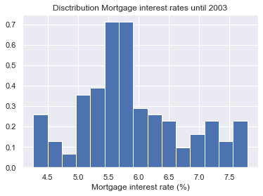

```python
# here i make a distribution graph of the numerical data column
ax=plt.axes()
plt.hist(np.asarray(MortgageRatesUntil2003.dropna().MortgageRate), 15, density=1);
ax.set_title('Disctribution Mortgage interest rates until 2003')
plt.xlabel('Mortgage interest rate (%)')
```

in this dataset are the following features:

- Onderwerp: the type of mortgage interest. originally there was average, highest and lowest, but I only downloaded the average one.
  - Gemiddelde hypotheekrente: the average mortgage interest rate from new contracts on normal mortgages
- YearMonth: the periods, most of the time a combination of year and month, but sometimes there is only a year (for the yearly average). from January 1994 to December 2003
- Percentage: the measurement that the mortgage interest rate is in.
- MortgageRate: the percentage of average mortgage interest rate. range: 4.26% to 7.80%

there are also no na's and the numerical data is normally distributed, but a bit skewed. I only got 10 years of data in this dataset, but that is why I searched for another dataset. I also think the data will be trustworthy because the data source is trustworthy (CBS).

#### 1.3.1.2 Mortgage interest rates from 2003

```python
#here i import the dataset with mortgage rates from 2003 and
#look into the datatypes and amount of null values etc
MortgageRatesFrom2003 = pd.read_csv('(01-04-22)_5_2_7_1_bvr_.csv')
print(MortgageRatesFrom2003.info())
MortgageRatesFrom2003
```

```
<class 'pandas.core.frame.DataFrame'>
RangeIndex: 2062 entries, 0 to 2061
Data columns (total 7 columns):
 #   Column                  Non-Null Count  Dtype
---  ------                  --------------  -----
 0   Balanszijde             2062 non-null   object
 1   Instrument              2062 non-null   object
 2   Stroomtype              2062 non-null   object
 3   LooptijdOorspronkelijk  2062 non-null   object
 4   RenteVastPeriode        2062 non-null   object
 5   Periode                 2062 non-null   object
 6   waarde                  2062 non-null   float64
dtypes: float64(1), object(6)
memory usage: 112.9+ KB
None
```

|  | Balanszijde | Instrument | Stroomtype | LooptijdOorspronkelijk | RenteVastPeriode | Periode | waarde |
| --- | --- | --- | --- | --- | --- | --- | --- |
| 0 | Activa | Woninghypotheken - Totaal | Uitstaande bedragen | Totaal | Totaal | 2003-01 | 5.65 |
| 1 | Activa | Woninghypotheken - Totaal | Uitstaande bedragen | Totaal | Totaal | 2003-02 | 5.62 |
| 2 | Activa | Woninghypotheken - Totaal | Uitstaande bedragen | Totaal | Totaal | 2003-03 | 5.59 |
| 3 | Activa | Woninghypotheken - Totaal | Uitstaande bedragen | Totaal | Totaal | 2003-04 | 5.55 |
| 4 | Activa | Woninghypotheken - Totaal | Uitstaande bedragen | Totaal | Totaal | 2003-05 | 5.52 |
| ... | ... | ... | ... | ... | ... | ... | ... |
| 2057 | Activa | Woninghypotheken - Totaal | Nieuwe contracten | Totaal | > 10 jaar * | 2021-10 | 1.75 |
| 2058 | Activa | Woninghypotheken - Totaal | Nieuwe contracten | Totaal | > 10 jaar * | 2021-11 | 1.75 |
| 2059 | Activa | Woninghypotheken - Totaal | Nieuwe contracten | Totaal | > 10 jaar * | 2021-12 | 1.73 |
| 2060 | Activa | Woninghypotheken - Totaal | Nieuwe contracten | Totaal | > 10 jaar * | 2022-01 | 1.77 |
| 2061 | Activa | Woninghypotheken - Totaal | Nieuwe contracten | Totaal | > 10 jaar * | 2022-02 | 1.76 |

2062 rows × 7 columns

```python
# here i look into the unique values of all the columns and the statistical summery
MortgageRatesFrom2003['Balanszijde'].unique()
MortgageRatesFrom2003['Instrument'].unique()
MortgageRatesFrom2003['Stroomtype'].unique()
MortgageRatesFrom2003['LooptijdOorspronkelijk'].unique()
MortgageRatesFrom2003['RenteVastPeriode'].unique()
MortgageRatesFrom2003['Periode '].unique()
MortgageRatesFrom2003['waarde'].unique()
MortgageRatesFrom2003.describe()
```

|  | waarde |
| --- | --- |
| count | 2062.000000 |
| mean | 3.766819 |
| std | 1.157802 |
| min | 1.530000 |
| 25% | 2.710000 |
| 50% | 4.040000 |
| 75% | 4.760000 |
| max | 6.030000 |

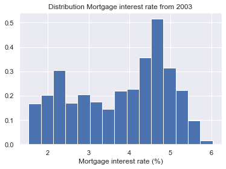

```python
# here i make a distribution diagram of the numerical data
ax=plt.axes()
plt.hist(np.asarray(MortgageRatesFrom2003.dropna().waarde), 15, density=1);
ax.set_title('Distribution Mortgage interest rate from 2003')
plt.xlabel('Mortgage interest rate (%)')
```

Features

- Balanszijde: balance side. is either activia or passivia, activia meaning assets and passivia meaning liabilities and equity
- Instrument: the subject that the data (in that row) is about. in our case we only downloaded the 'Woninghypotheken - Totaal' which translates to house mortgages total and it gives information about the mortgage interest rates
- Stroomtype: here I can either be 'nieuwe contracten' or 'uitstaande bedragen', which translates to new contracts and outstanding amounts.
- LooptijdOorspronkelijk: is the original duration of the mortgage.
- RenteVastPeriode: is the period that the interest rate is fixed
- Periode: the month and the year. range from January 2003 to February 2022
- waarde: the average mortgage interest rate in percentage. range 1.53 to 6.03

just like the other dataset, this data has 0 na's, but it doesn't seem to have a normal distribution. it does, however, make up for the 15 missing years of the other dataset, because this dataset is from 2003 to 2022, which makes up for a total of 29 years. this data comes from DNB which is also a very trustworthy source.

#### 1.3.1.3 Inflation

```python
#here i import the dataset with the inflation numbers and
#look into the datatypes and amount of null values etc
Inflation=pd.read_csv('Consumentenprijzen__prijsindex_2015_100_01042022_134258.csv', skiprows=5, sep=';', names=['YearMonth','CPI','CPI afgeleid','Maandmutatie CPI','Maandmutatie CPI afgeleid','Jaarmutatie CPI','Jaarmutatie CPI afgeleid','Wegingscoëfficiënt'], decimal=',', skipfooter=1, engine='python')
print(Inflation.info())
Inflation
# i skip the first 5 rows in the dataset then i change the column names by hand and delete the last row.
# i also put the seperator to ; and the decimal to ,
```

```
<class 'pandas.core.frame.DataFrame'>
RangeIndex: 340 entries, 0 to 339
Data columns (total 8 columns):
 #   Column                     Non-Null Count  Dtype
---  ------                     --------------  -----
 0   YearMonth                  340 non-null    object
 1   CPI                        340 non-null    float64
 2   CPI afgeleid               340 non-null    float64
 3   Maandmutatie CPI           313 non-null    float64
 4   Maandmutatie CPI afgeleid  313 non-null    float64
 5   Jaarmutatie CPI            327 non-null    float64
 6   Jaarmutatie CPI afgeleid   327 non-null    float64
 7   Wegingscoëfficiënt         340 non-null    int64
dtypes: float64(6), int64(1), object(1)
memory usage: 21.4+ KB
None
```

|  | YearMonth | CPI | CPI afgeleid | Maandmutatie CPI | Maandmutatie CPI afgeleid | Jaarmutatie CPI | Jaarmutatie CPI afgeleid | Wegingscoëfficiënt |
| --- | --- | --- | --- | --- | --- | --- | --- | --- |
| 0 | 1996 januari | 68.03 | 72.28 | NaN | NaN | NaN | NaN | 100000 |
| 1 | 1996 februari | 68.29 | 72.55 | 0.4 | 0.4 | NaN | NaN | 100000 |
| 2 | 1996 maart | 68.92 | 73.22 | 0.9 | 0.9 | NaN | NaN | 100000 |
| 3 | 1996 april | 69.13 | 73.44 | 0.3 | 0.3 | NaN | NaN | 100000 |
| 4 | 1996 mei | 68.96 | 73.26 | -0.2 | -0.2 | NaN | NaN | 100000 |
| ... | ... | ... | ... | ... | ... | ... | ... | ... |
| 335 | 2021 november | 113.17 | 111.29 | 0.9 | 0.9 | 5.2 | 5.0 | 100000 |
| 336 | 2021 december | 114.01 | 112.12 | 0.7 | 0.7 | 5.7 | 5.6 | 100000 |
| 337 | 2021 | 110.39 | 108.55 | NaN | NaN | 2.7 | 2.5 | 100000 |
| 338 | 2022 januari | 114.53 | 113.64 | 0.5 | 1.4 | 6.4 | 7.4 | 100000 |
| 339 | 2022 februari* | 115.27 | 114.37 | 0.6 | 0.6 | 6.2 | 7.1 | 100000 |

340 rows × 8 columns

```python
# here i look into the unique values of all the columns and the statistical summery
Inflation['YearMonth'].unique()
Inflation['CPI'].unique()
Inflation['CPI afgeleid'].unique()
Inflation['Maandmutatie CPI'].unique()
Inflation['Maandmutatie CPI afgeleid'].unique()
Inflation['Jaarmutatie CPI'].unique()
Inflation['Jaarmutatie CPI afgeleid'].unique()
Inflation['Wegingscoëfficiënt'].unique()
Inflation.describe()
```

|  | CPI | CPI afgeleid | Maandmutatie CPI | Maandmutatie CPI afgeleid | Jaarmutatie CPI | Jaarmutatie CPI afgeleid | Wegingscoëfficiënt |
| --- | --- | --- | --- | --- | --- | --- | --- |
| count | 340.000000 | 340.000000 | 313.000000 | 313.000000 | 327.000000 | 327.000000 | 340.0 |
| mean | 89.792794 | 91.527235 | 0.170927 | 0.146326 | 1.934251 | 1.623547 | 100000.0 |
| std | 12.176068 | 10.400808 | 0.474360 | 0.488648 | 0.990873 | 0.927409 | 0.0 |
| min | 68.030000 | 72.280000 | -1.100000 | -1.100000 | -0.200000 | -0.300000 | 100000.0 |
| 25% | 80.877500 | 83.915000 | -0.200000 | -0.200000 | 1.300000 | 1.100000 | 100000.0 |
| 50% | 90.000000 | 92.355000 | 0.100000 | 0.100000 | 1.900000 | 1.600000 | 100000.0 |
| 75% | 100.095000 | 100.207500 | 0.500000 | 0.500000 | 2.400000 | 1.950000 | 100000.0 |
| max | 115.270000 | 114.370000 | 1.300000 | 1.400000 | 6.400000 | 7.400000 | 100000.0 |

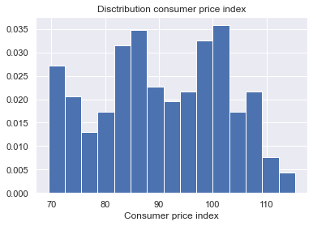

```python
# here i make a distribution diagram of the numerical data i am interested in
ax=plt.axes()
plt.hist(np.asarray(Inflation.dropna().CPI), 15, density=1);
ax.set_title('Disctribution consumer price index')
plt.xlabel('Consumer price index')
```

Features:

- YearMonth: the combination of month and year. range January 1996 to February 2022
- CPI: Consumer price index, Index number about the price developments from the basket of consumer goods and services from the average dutch household. range 68.03 to 115.27
- CPI afgeleid: its CPI without the changes in the product bound taxes, subsidies, and consumption-related taxes. range 72.2 to 114.37
- Maandmutatie CPI: the average price growth per month, based on the month before. range -1.1 to 1.3
- Maandmutatie CPI afgeleid: the average price growth per month, based on the month before. but without the changes in the product bound taxes, subsidies, and consumption-related taxes. range -1.1 to 1.4
- Jaarmutatie CPI: the average price growth per year, based on the year before. range -0.2 to 6.4
- Jaarmutatie CPI afgeleid: the average price growth per year, based on the year before. but without the changes in the product bound taxes, subsidies, and consumption-related taxes. range -0.3 to 7.4
- Wegingscoëfficiënt: the amount/proportion that a dutch household spends per product group. range always 100000

this data also does not seem to have a normal distribution, but again 0 na's. this data set does however have a bit more than 26 years' worth of data and is from CBS, which is a trustworthy source.

#### 1.3.1.4 Average House prices

```python
#here i import the dataset with the average house prices per house type and
#look into the datatypes and amount of null values etc
HousepricesTypesHouses=pd.read_csv('Bestaande_koopwoningen__verkoopprijzen__woningtype__prijsindex_2015_100_04042022_161025.csv', skiprows=5, sep=';', names=['Date', 'TypeHouse','PriceIndex','AveragePrice'], skipfooter=1, decimal=',', engine='python')
print(HousepricesTypesHouses.info())
HousepricesTypesHouses
# i skip the first 5 rows in the dataset then i change the column names by hand and delete the last row.
# i also put the seperator to ; and the decimal to ,
```

```
<class 'pandas.core.frame.DataFrame'>
RangeIndex: 945 entries, 0 to 944
Data columns (total 4 columns):
 #   Column        Non-Null Count  Dtype
---  ------        --------------  -----
 0   Date          945 non-null    object
 1   TypeHouse     945 non-null    object
 2   PriceIndex    945 non-null    float64
 3   AveragePrice  945 non-null    int64
dtypes: float64(1), int64(1), object(2)
memory usage: 29.7+ KB
None
```

|  | Date | TypeHouse | PriceIndex | AveragePrice |
| --- | --- | --- | --- | --- |
| 0 | 1995 1e kwartaal | Totaal woningen | 41.4 | 89792 |
| 1 | 1995 1e kwartaal | Eengezinswoningen | 41.7 | 97639 |
| 2 | 1995 1e kwartaal | Tussenwoning | 42.8 | 85536 |
| 3 | 1995 1e kwartaal | Hoekwoning | 42.3 | 92146 |
| 4 | 1995 1e kwartaal | 2-onder-1-kapwoning | 42.4 | 98194 |
| ... | ... | ... | ... | ... |
| 940 | 2021 | Tussenwoning | 165.7 | 354068 |
| 941 | 2021 | Hoekwoning | 165.1 | 368441 |
| 942 | 2021 | 2-onder-1-kapwoning | 159.8 | 401935 |
| 943 | 2021 | Vrijstaande woning | 154.8 | 571721 |
| 944 | 2021 | Appartement | 178.1 | 341061 |

945 rows × 4 columns

```python
# here i look into the unique values of all the columns and the statistical summery
HousepricesTypesHouses['Date'].unique()
HousepricesTypesHouses['TypeHouse'].unique()
HousepricesTypesHouses['PriceIndex'].unique()
HousepricesTypesHouses['AveragePrice'].unique()
HousepricesTypesHouses.describe()
```

|  | PriceIndex | AveragePrice |
| --- | --- | --- |
| count | 945.000000 | 945.000000 |
| mean | 100.030476 | 234352.207407 |
| std | 28.052892 | 86955.713406 |
| min | 38.200000 | 62502.000000 |
| 25% | 91.000000 | 182938.000000 |
| 50% | 103.100000 | 229484.000000 |
| 75% | 114.500000 | 278004.000000 |
| max | 189.100000 | 601539.000000 |

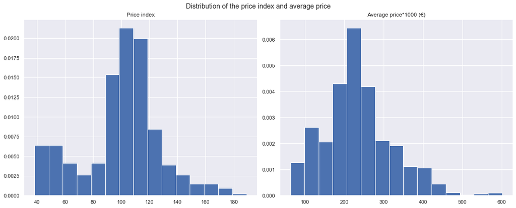

```python
# here i make a distribution diagram of the numerical data i am interested in
fig, ax = plt.subplots(1, 2, figsize=(15,6), constrained_layout = True)
fig.suptitle('Distribution of the price index and average price')
ax[0].hist(np.asarray(HousepricesTypesHouses.dropna().PriceIndex), 15, density=1);
ax[0].set_title("Price index")
ax[1].hist(np.asarray(HousepricesTypesHouses.dropna().AveragePrice/1000), 15, density=1);
ax[1].set_title("Average price*1000 (€)")
```

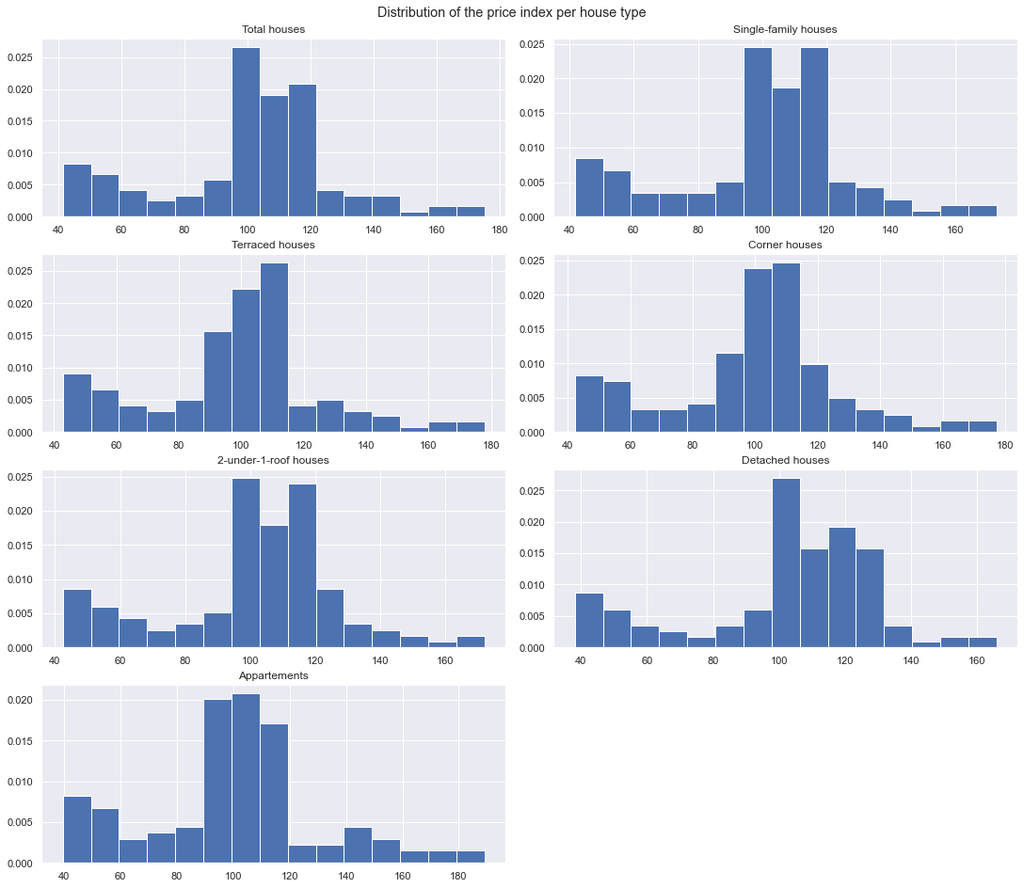

```python
#i first put every house type in its own datafram
TotalHouses=HousepricesTypesHouses[HousepricesTypesHouses['TypeHouse']=='Totaal woningen']
SingleFamilyHouses=HousepricesTypesHouses[HousepricesTypesHouses['TypeHouse']=='Eengezinswoningen']
InBetweenHouses=HousepricesTypesHouses[HousepricesTypesHouses['TypeHouse']=='Tussenwoning']
CornerHouses=HousepricesTypesHouses[HousepricesTypesHouses['TypeHouse']=='Hoekwoning']
TwoUnderOneRoofHouses=HousepricesTypesHouses[HousepricesTypesHouses['TypeHouse']=='2-onder-1-kapwoning']
DetachedHouses=HousepricesTypesHouses[HousepricesTypesHouses['TypeHouse']=='Vrijstaande woning']
Appartements=HousepricesTypesHouses[HousepricesTypesHouses['TypeHouse']=='Appartement']
#here i create a figure with 7 subplots in 4 rows and 2 columns
fig, ax = plt.subplots(4, 2, figsize=(15,13), constrained_layout = True)
fig.suptitle('Distribution of the price index per house type')
ax[0,0].hist(np.asarray(TotalHouses.dropna().PriceIndex), 15, density=1);
ax[0,0].set_title("Total houses")
ax[0,1].hist(np.asarray(SingleFamilyHouses.dropna().PriceIndex), 15, density=1);
ax[0,1].set_title("Single-family houses")
ax[1,0].hist(np.asarray(InBetweenHouses.dropna().PriceIndex), 15, density=1);
ax[1,0].set_title("Terraced houses")
ax[1,1].hist(np.asarray(CornerHouses.dropna().PriceIndex), 15, density=1);
ax[1,1].set_title("Corner houses")
ax[2,0].hist(np.asarray(TwoUnderOneRoofHouses.dropna().PriceIndex), 15, density=1);
ax[2,0].set_title("2-under-1-roof houses")
ax[2,1].hist(np.asarray(DetachedHouses.dropna().PriceIndex), 15, density=1);
ax[2,1].set_title("Detached houses")
ax[3,0].hist(np.asarray(Appartements.dropna().PriceIndex), 15, density=1);
ax[3,0].set_title("Appartements")
ax[3,1].set_axis_off()
```

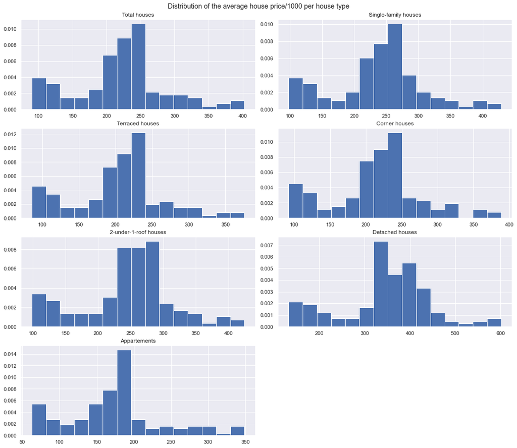

```python
#here i create a figure with 7 subplots in 4 rows and 2 columns
fig, ax = plt.subplots(4, 2, figsize=(15,13), constrained_layout = True)
fig.suptitle('Distribution of the average house price/1000 per house type')
ax[0,0].hist(np.asarray(TotalHouses.dropna().AveragePrice/1000), 15, density=1);
ax[0,0].set_title("Total houses")
ax[0,1].hist(np.asarray(SingleFamilyHouses.dropna().AveragePrice/1000), 15, density=1);
ax[0,1].set_title("Single-family houses")
ax[1,0].hist(np.asarray(InBetweenHouses.dropna().AveragePrice/1000), 15, density=1);
ax[1,0].set_title("Terraced houses")
ax[1,1].hist(np.asarray(CornerHouses.dropna().AveragePrice/1000), 15, density=1);
ax[1,1].set_title("Corner houses")
ax[2,0].hist(np.asarray(TwoUnderOneRoofHouses.dropna().AveragePrice/1000), 15, density=1);
ax[2,0].set_title("2-under-1-roof houses")
ax[2,1].hist(np.asarray(DetachedHouses.dropna().AveragePrice/1000), 15, density=1);
ax[2,1].set_title("Detached houses")
ax[3,0].hist(np.asarray(Appartements.dropna().AveragePrice/1000), 15, density=1);
ax[3,0].set_title("Appartements")
ax[3,1].set_axis_off()
```

features

- Date: Combination of Year and quarter. range 1995 1st quarter to 2021 4th quarter.
- TypeHouse: the type of house. the options with translation are: Totaal woningen: Total houses, Eengezinswoningen: Single-family houses, Tussenwoning: literally 'in-between houses' but the English name is terraced houses, Hoekwoning: Corner houses, 2-onder-1-kapwoning: 2-under-1-roof houses, Vrijstaande woning: Detached houses and Appartement which is the same in English
- PriceIndex: defines the price changes of the supply of existing houses. range 38.2 to 189.1
- AveragePrice: the average price of a certain type of house at a certain type, bases amount paid to that type of house in that period. (so not the asking price but what the new owners actually paid for it.). range 62502 to 601539

this data is normally distributed and has 27 years' worth of data and also has 0 na's and it is just like the other data from a trustworthy data source (CBS). The price index data is more similarly distributed to each other (the different types of houses) than the average price is.

## 1.4 Data Preperation

in this part of the data provisioning, I am going to clean my data.

### 1.4.1 Cleaning

#### 1.4.1.1 Mortgage interests rates until 2003 dataset

```python
#first i check if the columns onderwerp and percentage have more then one different entity,
#but it didnt have that so i can delete those columns
print(MortgageRatesUntil2003['Onderwerp'].unique())
print(MortgageRatesUntil2003['Percentage'].unique())
MortgageRatesUntil2003 = MortgageRatesUntil2003[['YearMonth','MortgageRate']]
#then i seperate the year and month in the YearMonth column, so i make an actualy date from it.
#To do that i make the seperated year an integer and use the map function to map the right number for each
#month.
MortgageRatesUntil2003[['Year','Month']]= MortgageRatesUntil2003['YearMonth'].str.split(' ', expand = True)
MortgageRatesUntil2003['Year']=MortgageRatesUntil2003['Year'].astype(int)
print(MortgageRatesUntil2003['Month'].unique())
MortgageRatesUntil2003['MonthNumber'] = MortgageRatesUntil2003['Month'].map( {'januari': '01', 'februari': '02', 'maart': '03', 'april':'04', 'mei':'05', 'juni':'06', 'juli':'07', 'augustus':'08', 'september':'09', 'oktober':'10', 'november':'11', 'december':'12'})
#then i check the datatypes and more importantly the na's and drop the na's becuase those are the overal
#number per year
print(MortgageRatesUntil2003.info())
MortgageRatesUntil2003=MortgageRatesUntil2003.dropna()
#then i create a string in a date format with the column year and monthnumber and then convert it to a
#date type after that i create a new column with the year and quarter becuase one of the datasets is per
#quarter instead of per month
MortgageRatesUntil2003['Date']=MortgageRatesUntil2003['Year'].astype(str) + '-' + MortgageRatesUntil2003['MonthNumber'].astype(str) + '-01'
MortgageRatesUntil2003['Date']= pd.to_datetime(MortgageRatesUntil2003['Date'])
MortgageRatesUntil2003['YearQuarter'] = MortgageRatesUntil2003['Date'].dt.to_period('Q')
#then i check the information about the dataframe againa nd only save the usefull columns in a new
#'cleaned' dataset
print(MortgageRatesUntil2003.info())
MortgageRatesUntil2003Cleaned= MortgageRatesUntil2003[['Date','YearQuarter','MortgageRate']]
MortgageRatesUntil2003Cleaned
```

```
['Gemiddelde hypotheekrente']
['procent']
[None 'januari' 'februari' 'maart' 'april' 'mei' 'juni' 'juli' 'augustus'
 'september' 'oktober' 'november' 'december']
<class 'pandas.core.frame.DataFrame'>
RangeIndex: 131 entries, 0 to 130
Data columns (total 5 columns):
 #   Column        Non-Null Count  Dtype
---  ------        --------------  -----
 0   YearMonth     131 non-null    object
 1   MortgageRate  131 non-null    float64
 2   Year          131 non-null    int32
 3   Month         120 non-null    object
 4   MonthNumber   120 non-null    object
dtypes: float64(1), int32(1), object(3)
memory usage: 4.7+ KB
None
<class 'pandas.core.frame.DataFrame'>
Int64Index: 120 entries, 1 to 129
Data columns (total 7 columns):
 #   Column        Non-Null Count  Dtype
---  ------        --------------  -----
 0   YearMonth     120 non-null    object
 1   MortgageRate  120 non-null    float64
 2   Year          120 non-null    int32
 3   Month         120 non-null    object
 4   MonthNumber   120 non-null    object
 5   Date          120 non-null    datetime64[ns]
 6   YearQuarter   120 non-null    period[Q-DEC]
dtypes: datetime64[ns](1), float64(1), int32(1), object(3), period[Q-DEC](1)
memory usage: 7.0+ KB
None
```

|  | Date | YearQuarter | MortgageRate |
| --- | --- | --- | --- |
| 1 | 1994-01-01 | 1994Q1 | 6.93 |
| 2 | 1994-02-01 | 1994Q1 | 6.84 |
| 3 | 1994-03-01 | 1994Q1 | 6.88 |
| 4 | 1994-04-01 | 1994Q2 | 6.93 |
| 5 | 1994-05-01 | 1994Q2 | 7.01 |
| ... | ... | ... | ... |
| 125 | 2003-08-01 | 2003Q3 | 4.28 |
| 126 | 2003-09-01 | 2003Q3 | 4.35 |
| 127 | 2003-10-01 | 2003Q4 | 4.42 |
| 128 | 2003-11-01 | 2003Q4 | 4.48 |
| 129 | 2003-12-01 | 2003Q4 | 4.52 |

120 rows × 3 columns

```python
#here i calculate the mean per quarter (and year)
MortgageRatesUntil2003Cleaned['QuarterlyRate']=MortgageRatesUntil2003Cleaned.groupby('YearQuarter')['MortgageRate'].transform(np.mean)
MortgageRatesUntil2003Cleaned
```

|  | Date | YearQuarter | MortgageRate | QuarterlyRate |
| --- | --- | --- | --- | --- |
| 1 | 1994-01-01 | 1994Q1 | 6.93 | 6.883333 |
| 2 | 1994-02-01 | 1994Q1 | 6.84 | 6.883333 |
| 3 | 1994-03-01 | 1994Q1 | 6.88 | 6.883333 |
| 4 | 1994-04-01 | 1994Q2 | 6.93 | 7.030000 |
| 5 | 1994-05-01 | 1994Q2 | 7.01 | 7.030000 |
| ... | ... | ... | ... | ... |
| 125 | 2003-08-01 | 2003Q3 | 4.28 | 4.296667 |
| 126 | 2003-09-01 | 2003Q3 | 4.35 | 4.296667 |
| 127 | 2003-10-01 | 2003Q4 | 4.42 | 4.473333 |
| 128 | 2003-11-01 | 2003Q4 | 4.48 | 4.473333 |
| 129 | 2003-12-01 | 2003Q4 | 4.52 | 4.473333 |

120 rows × 4 columns

#### 1.4.1.2 Mortgage interest rates from 2003 dataset

```python
#here i check how many different entities are in the columns and i find out that i can delete the first 2
#because there is only one different entity. i also check the names of the columns
MortgageRatesFrom2003['Balanszijde'].unique()
MortgageRatesFrom2003['Instrument'].unique()
MortgageRatesFrom2003['Stroomtype'].unique()
MortgageRatesFrom2003['LooptijdOorspronkelijk'].unique()
MortgageRatesFrom2003['RenteVastPeriode'].unique()
MortgageRatesFrom2003.columns.unique()
#here i first make the dates in a date format and then covert it to a datatype and look at the
#information of the dataframe and the changed dataframe itself
MortgageRatesFrom2003['Date']= MortgageRatesFrom2003['Periode '].astype(str) + "-01"
MortgageRatesFrom2003['Date']= pd.to_datetime(MortgageRatesFrom2003['Date'])
print(MortgageRatesFrom2003.info())
MortgageRatesFrom2003
# then i make a new column with year and quarter which i create with the date and save the interesting
#columns in a dataset
MortgageRatesFrom2003['YearQuarter'] = MortgageRatesFrom2003['Date'].dt.to_period('Q')
MortgageRatesFrom2003Cleaned = MortgageRatesFrom2003[['Date', 'YearQuarter','Stroomtype','LooptijdOorspronkelijk','RenteVastPeriode','waarde']]
#then i create a dataset called research to research into the values of 2003 compared to the other
#dataset 2003
Research=MortgageRatesFrom2003Cleaned[(MortgageRatesFrom2003Cleaned['Date'] <= '2003-12-01')&(MortgageRatesFrom2003Cleaned['Stroomtype']=='Nieuwe contracten ')]
Research
MortgageRatesFrom2003Cleaned
```

```
<class 'pandas.core.frame.DataFrame'>
RangeIndex: 2062 entries, 0 to 2061
Data columns (total 8 columns):
 #   Column                  Non-Null Count  Dtype
---  ------                  --------------  -----
 0   Balanszijde             2062 non-null   object
 1   Instrument              2062 non-null   object
 2   Stroomtype              2062 non-null   object
 3   LooptijdOorspronkelijk  2062 non-null   object
 4   RenteVastPeriode        2062 non-null   object
 5   Periode                 2062 non-null   object
 6   waarde                  2062 non-null   float64
 7   Date                    2062 non-null   datetime64[ns]
dtypes: datetime64[ns](1), float64(1), object(6)
memory usage: 129.0+ KB
None
```

|  | Date | YearQuarter | Stroomtype | LooptijdOorspronkelijk | RenteVastPeriode | waarde |
| --- | --- | --- | --- | --- | --- | --- |
| 0 | 2003-01-01 | 2003Q1 | Uitstaande bedragen | Totaal | Totaal | 5.65 |
| 1 | 2003-02-01 | 2003Q1 | Uitstaande bedragen | Totaal | Totaal | 5.62 |
| 2 | 2003-03-01 | 2003Q1 | Uitstaande bedragen | Totaal | Totaal | 5.59 |
| 3 | 2003-04-01 | 2003Q2 | Uitstaande bedragen | Totaal | Totaal | 5.55 |
| 4 | 2003-05-01 | 2003Q2 | Uitstaande bedragen | Totaal | Totaal | 5.52 |
| ... | ... | ... | ... | ... | ... | ... |
| 2057 | 2021-10-01 | 2021Q4 | Nieuwe contracten | Totaal | > 10 jaar * | 1.75 |
| 2058 | 2021-11-01 | 2021Q4 | Nieuwe contracten | Totaal | > 10 jaar * | 1.75 |
| 2059 | 2021-12-01 | 2021Q4 | Nieuwe contracten | Totaal | > 10 jaar * | 1.73 |
| 2060 | 2022-01-01 | 2022Q1 | Nieuwe contracten | Totaal | > 10 jaar * | 1.77 |
| 2061 | 2022-02-01 | 2022Q1 | Nieuwe contracten | Totaal | > 10 jaar * | 1.76 |

2062 rows × 6 columns

#### 1.4.1.3 looking into 2003 from the mortgage interest rates until 2003 vs from 2003

```
<class 'pandas.core.frame.DataFrame'>
Int64Index: 12 entries, 118 to 129
Data columns (total 4 columns):
 #   Column            Non-Null Count  Dtype
---  ------            --------------  -----
 0   Date              12 non-null     datetime64[ns]
 1   YearQuarter       12 non-null     period[Q-DEC]
 2   RenteVastPeriode  12 non-null     object
 3   MortgageRate      12 non-null     float64
dtypes: datetime64[ns](1), float64(1), object(1), period[Q-DEC](1)
memory usage: 480.0+ bytes
None
<class 'pandas.core.frame.DataFrame'>
Int64Index: 60 entries, 912 to 1843
Data columns (total 4 columns):
 #   Column            Non-Null Count  Dtype
---  ------            --------------  -----
 0   Date              60 non-null     datetime64[ns]
 1   YearQuarter       60 non-null     period[Q-DEC]
 2   RenteVastPeriode  60 non-null     object
 3   MortgageRate      60 non-null     float64
dtypes: datetime64[ns](1), float64(1), object(1), period[Q-DEC](1)
memory usage: 2.3+ KB
None
```

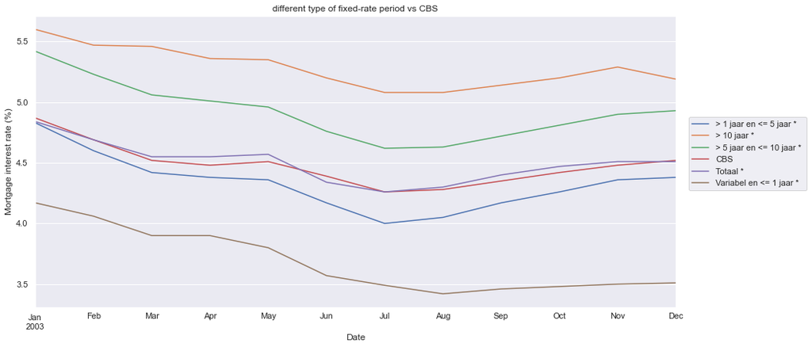

```python
#here i make a dataset with 2003 from the other dataset and create a column tentevastperiode that is
#filled with cbs so i can (after saving the columns i need) concat the 2 datasets and look the
#differences
ResearchUntil2003=MortgageRatesUntil2003Cleaned[MortgageRatesUntil2003Cleaned['Date']>='2003-01-01']
ResearchUntil2003['RenteVastPeriode']='CBS'
ResearchUntil2003=ResearchUntil2003[['Date','YearQuarter','RenteVastPeriode','MortgageRate']]
ResearchUntil2003
# here i check the unique entities in the rente vaste periode from the dataset from 2003 and save
#the dataframe under a more logical name
Research['RenteVastPeriode'].unique()
ResearchFrom2003= Research
#then i make sure that i have all the same column names in the from 2003 dataset as in the untill 2003
#dataset so i can concat the 2
ResearchFrom2003['MortgageRate']=ResearchFrom2003['waarde']
ResearchFrom2003 = ResearchFrom2003[['Date','YearQuarter','RenteVastPeriode','MortgageRate']]
ResearchFrom2003
#before the concat i check the information of the 2 dataframes and then do the concat and save the new
#dataframe (and sort it by date)
print(ResearchUntil2003.info())
print(ResearchFrom2003.info())
ResearchTogether=pd.concat([ResearchUntil2003,ResearchFrom2003])
ResearchTogether.sort_values('Date')
#here i create a line plot with each type of mortgage rate from the from 2003 and the cbs as different
#line so i can see which line is the closest
ResearchTogether.pivot_table(values="MortgageRate", index="Date", columns="RenteVastPeriode").plot(figsize=(15,7))
plt.ylabel("Mortgage interest rate (%)")
plt.title('different type of fixed-rate period vs CBS')
plt.legend(loc=(1.02,0.4))
#the values in the dataset untill 2003 are a bit different, this can be because the dataset until 2003
#has a 5 year fixed interested (cus some other numbers are about the 5 year fixed rates in this dataset)
#and in the dataset from 2003 that is grouped together with the fixed interest periods from 1 to 5 years
#or the values in the dataset untill 2003 are also totals but differently calculated
```

Based on the line plot the total values from the from 2003 dataset are very similar to the numbers from the number from the until 2003 dataset. This seems to indicate that the reason for the difference is indeed just a different way of calculating but that is and stays an assumption. But because the numbers are so similar I can still use both datasets.

#### 1.4.1.4 further cleaning the mortgage interests rates datasets

```python
#here i change the from 2003 dataset based on my findings in the graph above. To do that i filter it first
#and then make sure that i have the same column names as the until 2003 and save the needed columns
print(MortgageRatesUntil2003Cleaned)
MortgageRatesFrom2003Cleaned=MortgageRatesFrom2003Cleaned[(MortgageRatesFrom2003Cleaned['Stroomtype']=='Nieuwe contracten ') & (MortgageRatesFrom2003Cleaned['RenteVastPeriode']=='Totaal * ')]
MortgageRatesFrom2003Cleaned['MortgageRate']=MortgageRatesFrom2003Cleaned['waarde']
MortgageRatesFrom2003Cleaned=MortgageRatesFrom2003Cleaned[['Date','YearQuarter','MortgageRate']]
#here i calculate the quarterly mortgage rate and save it in a new column
MortgageRatesFrom2003Cleaned['QuarterlyRate']=MortgageRatesFrom2003Cleaned.groupby('YearQuarter')['MortgageRate'].transform(np.mean)
MortgageRatesFrom2003Cleaned
```

```
          Date YearQuarter  MortgageRate  QuarterlyRate
1   1994-01-01      1994Q1          6.93       6.883333
2   1994-02-01      1994Q1          6.84       6.883333
3   1994-03-01      1994Q1          6.88       6.883333
4   1994-04-01      1994Q2          6.93       7.030000
5   1994-05-01      1994Q2          7.01       7.030000
..         ...         ...           ...            ...
125 2003-08-01      2003Q3          4.28       4.296667
126 2003-09-01      2003Q3          4.35       4.296667
127 2003-10-01      2003Q4          4.42       4.473333
128 2003-11-01      2003Q4          4.48       4.473333
129 2003-12-01      2003Q4          4.52       4.473333

[120 rows x 4 columns]
```

|  | Date | YearQuarter | MortgageRate | QuarterlyRate |
| --- | --- | --- | --- | --- |
| 912 | 2003-01-01 | 2003Q1 | 4.84 | 4.693333 |
| 913 | 2003-02-01 | 2003Q1 | 4.69 | 4.693333 |
| 914 | 2003-03-01 | 2003Q1 | 4.55 | 4.693333 |
| 915 | 2003-04-01 | 2003Q2 | 4.55 | 4.486667 |
| 916 | 2003-05-01 | 2003Q2 | 4.57 | 4.486667 |
| ... | ... | ... | ... | ... |
| 1137 | 2021-10-01 | 2021Q4 | 1.65 | 1.650000 |
| 1138 | 2021-11-01 | 2021Q4 | 1.65 | 1.650000 |
| 1139 | 2021-12-01 | 2021Q4 | 1.65 | 1.650000 |
| 1140 | 2022-01-01 | 2022Q1 | 1.67 | 1.670000 |
| 1141 | 2022-02-01 | 2022Q1 | 1.67 | 1.670000 |

230 rows × 4 columns

#### 1.4.1.5 Looking further into the best option for 2003 from the mortgage interest rates datatsets

```python
#here i first look into the 2 cleaned dataset with the mortgage rates
print(MortgageRatesFrom2003Cleaned)
print(MortgageRatesUntil2003Cleaned)
#then i save per each of those 2 datasets only 2003, save the mortgagerate abd quarterly rate under a
#different name so i can get the mean later and after that also make a datafram without 2003
MortgageRatesUntil2003Cleaned_Only2003=MortgageRatesUntil2003Cleaned[MortgageRatesUntil2003Cleaned['Date']>='2003-01-01']
MortgageRatesUntil2003Cleaned_Only2003['MortgageRate1']=MortgageRatesUntil2003Cleaned_Only2003['MortgageRate']
MortgageRatesUntil2003Cleaned_Only2003['QuarterlyMortgageRate1']=MortgageRatesUntil2003Cleaned_Only2003['QuarterlyRate']
MortgageRatesUntil2003Cleaned_Without2003=MortgageRatesUntil2003Cleaned[MortgageRatesUntil2003Cleaned['Date']<'2003-01-01']
MortgageRatesFrom2003Cleaned_Only2003=MortgageRatesFrom2003Cleaned[MortgageRatesFrom2003Cleaned['Date']<='2003-12-01']
MortgageRatesFrom2003Cleaned_Only2003['MortgageRate2']=MortgageRatesFrom2003Cleaned_Only2003['MortgageRate']
MortgageRatesFrom2003Cleaned_Only2003['QuarterlyMortgageRate2']=MortgageRatesFrom2003Cleaned_Only2003['QuarterlyRate']
MortgageRatesFrom2003Cleaned_Without2003=MortgageRatesFrom2003Cleaned[MortgageRatesFrom2003Cleaned['Date']>'2003-12-01']
#then i add together the 2 datasets with only 2003 and get the mean values of the 2 mortgage rates per
#month and quarter. after that i save only the needed columns
MortgageRates2003=pd.concat([MortgageRatesUntil2003Cleaned_Only2003.reset_index(drop=True), MortgageRatesFrom2003Cleaned_Only2003.reset_index(drop=True)],axis=1)
MortgageRates2003['MortgageRate']=MortgageRates2003[['MortgageRate1', 'MortgageRate2']].mean(axis=1)
MortgageRates2003['QuarterlyRate']=MortgageRates2003[['QuarterlyMortgageRate1', 'QuarterlyMortgageRate2']].mean(axis=1)
MortgageRates2003=MortgageRates2003.iloc[:, [0, 1, 2, 3]]
MortgageRates2003
```

```
           Date YearQuarter  MortgageRate  QuarterlyRate
912  2003-01-01      2003Q1          4.84       4.693333
913  2003-02-01      2003Q1          4.69       4.693333
914  2003-03-01      2003Q1          4.55       4.693333
915  2003-04-01      2003Q2          4.55       4.486667
916  2003-05-01      2003Q2          4.57       4.486667
...         ...         ...           ...            ...
1137 2021-10-01      2021Q4          1.65       1.650000
1138 2021-11-01      2021Q4          1.65       1.650000
1139 2021-12-01      2021Q4          1.65       1.650000
1140 2022-01-01      2022Q1          1.67       1.670000
1141 2022-02-01      2022Q1          1.67       1.670000

[230 rows x 4 columns]
          Date YearQuarter  MortgageRate  QuarterlyRate
1   1994-01-01      1994Q1          6.93       6.883333
2   1994-02-01      1994Q1          6.84       6.883333
3   1994-03-01      1994Q1          6.88       6.883333
4   1994-04-01      1994Q2          6.93       7.030000
5   1994-05-01      1994Q2          7.01       7.030000
..         ...         ...           ...            ...
125 2003-08-01      2003Q3          4.28       4.296667
126 2003-09-01      2003Q3          4.35       4.296667
127 2003-10-01      2003Q4          4.42       4.473333
128 2003-11-01      2003Q4          4.48       4.473333
129 2003-12-01      2003Q4          4.52       4.473333

[120 rows x 4 columns]
```

|  | Date | YearQuarter | MortgageRate | QuarterlyRate |
| --- | --- | --- | --- | --- |
| 0 | 2003-01-01 | 2003Q1 | 4.855 | 4.693333 |
| 1 | 2003-02-01 | 2003Q1 | 4.690 | 4.693333 |
| 2 | 2003-03-01 | 2003Q1 | 4.535 | 4.693333 |
| 3 | 2003-04-01 | 2003Q2 | 4.515 | 4.473333 |
| 4 | 2003-05-01 | 2003Q2 | 4.540 | 4.473333 |
| 5 | 2003-06-01 | 2003Q2 | 4.365 | 4.473333 |
| 6 | 2003-07-01 | 2003Q3 | 4.260 | 4.308333 |
| 7 | 2003-08-01 | 2003Q3 | 4.290 | 4.308333 |
| 8 | 2003-09-01 | 2003Q3 | 4.375 | 4.308333 |
| 9 | 2003-10-01 | 2003Q4 | 4.445 | 4.485000 |
| 10 | 2003-11-01 | 2003Q4 | 4.495 | 4.485000 |
| 11 | 2003-12-01 | 2003Q4 | 4.515 | 4.485000 |

```python
#here i select the column i need from the only 2003 dataset and make sure they are the same so i can concat it easier.
MortgageRatesUntil2003Cleaned_Only2003 = MortgageRatesUntil2003Cleaned_Only2003[['Date','YearQuarter','MortgageRate','QuarterlyRate']]
MortgageRatesFrom2003Cleaned_Only2003 = MortgageRatesFrom2003Cleaned_Only2003[['Date','YearQuarter','MortgageRate','QuarterlyRate']]
#here i concat everything together in the 3 possible options: option1=with 2003 being the average of the 2 datasets,
#option2=2003 from the until 2003 dataset and option3=2003 from the from 2003 dataset
option1=pd.concat([MortgageRatesUntil2003Cleaned_Without2003, MortgageRates2003, MortgageRatesFrom2003Cleaned_Without2003])
option2=pd.concat([MortgageRatesUntil2003Cleaned_Without2003, MortgageRatesUntil2003Cleaned_Only2003, MortgageRatesFrom2003Cleaned_Without2003])
option3=pd.concat([MortgageRatesUntil2003Cleaned_Without2003, MortgageRatesFrom2003Cleaned_Only2003, MortgageRatesFrom2003Cleaned_Without2003])
#then i set everyindex to date and keep the date column in the dataset
option1.set_index('Date', inplace=True, drop=False)
option2.set_index('Date', inplace=True, drop=False)
option3.set_index('Date', inplace=True, drop=False)
print(option1)
print(option2)
print(option3)
```

```
                 Date YearQuarter  MortgageRate  QuarterlyRate
Date
1994-01-01 1994-01-01      1994Q1          6.93       6.883333
1994-02-01 1994-02-01      1994Q1          6.84       6.883333
1994-03-01 1994-03-01      1994Q1          6.88       6.883333
1994-04-01 1994-04-01      1994Q2          6.93       7.030000
1994-05-01 1994-05-01      1994Q2          7.01       7.030000
...               ...         ...           ...            ...
2021-10-01 2021-10-01      2021Q4          1.65       1.650000
2021-11-01 2021-11-01      2021Q4          1.65       1.650000
2021-12-01 2021-12-01      2021Q4          1.65       1.650000
2022-01-01 2022-01-01      2022Q1          1.67       1.670000
2022-02-01 2022-02-01      2022Q1          1.67       1.670000

[338 rows x 4 columns]
                 Date YearQuarter  MortgageRate  QuarterlyRate
Date
1994-01-01 1994-01-01      1994Q1          6.93       6.883333
1994-02-01 1994-02-01      1994Q1          6.84       6.883333
1994-03-01 1994-03-01      1994Q1          6.88       6.883333
1994-04-01 1994-04-01      1994Q2          6.93       7.030000
1994-05-01 1994-05-01      1994Q2          7.01       7.030000
...               ...         ...           ...            ...
2021-10-01 2021-10-01      2021Q4          1.65       1.650000
2021-11-01 2021-11-01      2021Q4          1.65       1.650000
2021-12-01 2021-12-01      2021Q4          1.65       1.650000
2022-01-01 2022-01-01      2022Q1          1.67       1.670000
2022-02-01 2022-02-01      2022Q1          1.67       1.670000

[338 rows x 4 columns]
                 Date YearQuarter  MortgageRate  QuarterlyRate
Date
1994-01-01 1994-01-01      1994Q1          6.93       6.883333
1994-02-01 1994-02-01      1994Q1          6.84       6.883333
1994-03-01 1994-03-01      1994Q1          6.88       6.883333
1994-04-01 1994-04-01      1994Q2          6.93       7.030000
1994-05-01 1994-05-01      1994Q2          7.01       7.030000
...               ...         ...           ...            ...
2021-10-01 2021-10-01      2021Q4          1.65       1.650000
2021-11-01 2021-11-01      2021Q4          1.65       1.650000
2021-12-01 2021-12-01      2021Q4          1.65       1.650000
2022-01-01 2022-01-01      2022Q1          1.67       1.670000
2022-02-01 2022-02-01      2022Q1          1.67       1.670000

[338 rows x 4 columns]
```

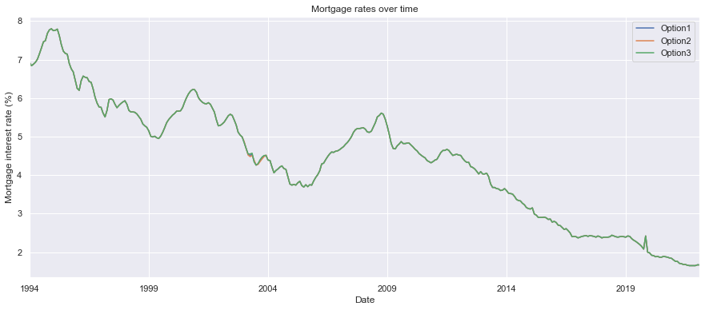

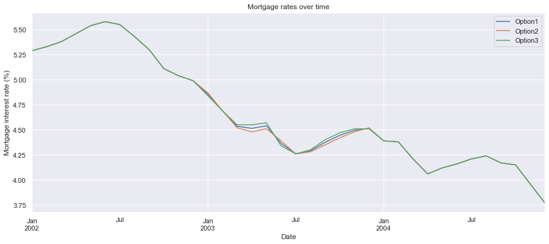

```python
#here i plot the 3 options in one plot with different lines to see which one blents in better. i first give the overal view and
#then one with only 2002-2004
ax = option1.plot(x='Date', y='MortgageRate', title='Mortgage rates over time', figsize=(15,6), label='Option1')
option2.plot(x='Date', y='MortgageRate', title='Mortgage rates over time', figsize=(15,6), ax=ax, label='Option2')
option3.plot(x='Date', y='MortgageRate', title='Mortgage rates over time', figsize=(15,6), ax=ax, label='Option3')
plt.ylabel("Mortgage interest rate (%)")

ax = option1[(option1['Date']<='2004-12-01') & (option1['Date']>='2002-01-01')].plot(x='Date', y='MortgageRate', title='Mortgage rates over time', figsize=(15,6), label='Option1')
option2[(option1['Date']<='2004-12-01') & (option1['Date']>='2002-01-01')].plot(x='Date', y='MortgageRate', title='Mortgage rates over time', figsize=(15,6), ax=ax, label='Option2')
option3[(option1['Date']<='2004-12-01') & (option1['Date']>='2002-01-01')].plot(x='Date', y='MortgageRate', title='Mortgage rates over time', figsize=(15,6), ax=ax, label='Option3')
plt.ylabel("Mortgage interest rate (%)")
```

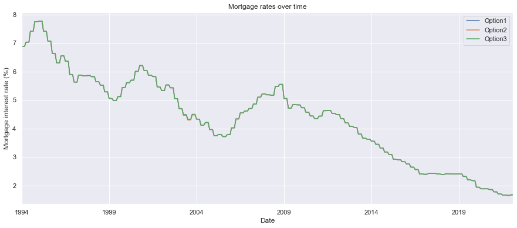

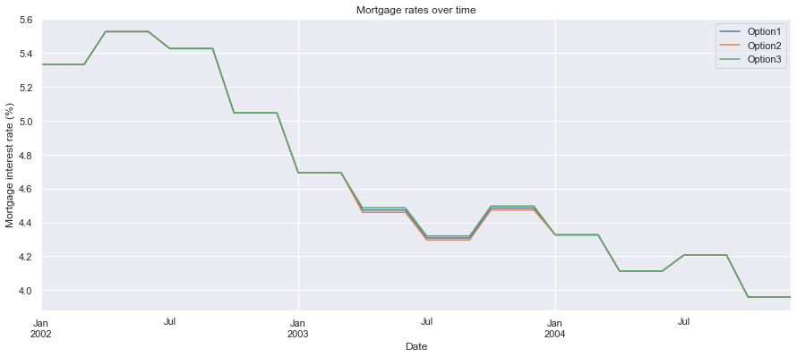

```python
#then i do the same here with instead of the monthly rates the quarterly rates
ax=option1.plot(x='Date', y='QuarterlyRate', title='Mortgage rates over time', figsize=(15,6), label='Option1')
option2.plot(x='Date', y='QuarterlyRate', title='Mortgage rates over time', figsize=(15,6), ax=ax, label='Option2')
option3.plot(x='Date', y='QuarterlyRate', title='Mortgage rates over time', figsize=(15,6), ax=ax, label='Option3')
plt.ylabel("Mortgage interest rate (%)")

ax = option1[(option1['Date']<='2004-12-01') & (option1['Date']>='2002-01-01')].plot(x='Date', y='QuarterlyRate', title='Mortgage rates over time', figsize=(15,6), label='Option1')
option2[(option1['Date']<='2004-12-01') & (option1['Date']>='2002-01-01')].plot(x='Date', y='QuarterlyRate', title='Mortgage rates over time', figsize=(15,6), ax=ax, label='Option2')
option3[(option1['Date']<='2004-12-01') & (option1['Date']>='2002-01-01')].plot(x='Date', y='QuarterlyRate', title='Mortgage rates over time', figsize=(15,6), ax=ax, label='Option3')
plt.ylabel("Mortgage interest rate (%)")
```

The different options are so close together that all of them could be used, but just to be safe I choose the average aka option 1.

#### 1.4.1.6 Inflation dataset

```python
#I first select the interesting columns and save it. after that i split the year month column, make the year a int put the
#monthnames to numbers.
Inflation = Inflation[['YearMonth','CPI']]
Inflation[['Year','Month']]= Inflation['YearMonth'].str.split(' ', expand = True)
Inflation['Year']= Inflation['Year'].astype(int)
Inflation['Month'].unique()
Inflation['MonthNumber'] = Inflation['Month'].map( {'januari': '01', 'februari': '02', 'maart': '03', 'april':'04', 'mei':'05', 'juni':'06', 'juli':'07', 'augustus':'08', 'september':'09', 'oktober':'10', 'november':'11', 'december':'12', 'februari*':'02'})
#here i check the na's and see that those na's are the overall year number so i delete them
print(Inflation.info())
print(Inflation[Inflation['MonthNumber'].isna()])
Inflation=Inflation.dropna()
#then i make the year and month in a date format and convert it to a date, then i create the year and quarter from the date
Inflation['Date'] = Inflation['Year'].astype(str) + '-' +Inflation['MonthNumber'].astype(str) + '-01'
Inflation['Date'] = pd.to_datetime(Inflation['Date'])
print(Inflation.info())
Inflation['YearQuarter'] = Inflation['Date'].dt.to_period('Q')
#then i save the interested columns and calculate the average of the CPI per quarter
InflationCleaned=Inflation[['Date','YearQuarter','Year','CPI']]
InflationCleaned['QuarterlyCPI']=InflationCleaned.groupby('YearQuarter')['CPI'].transform(np.mean)
InflationCleaned
```

```
<class 'pandas.core.frame.DataFrame'>
RangeIndex: 340 entries, 0 to 339
Data columns (total 5 columns):
 #   Column       Non-Null Count  Dtype
---  ------       --------------  -----
 0   YearMonth    340 non-null    object
 1   CPI          340 non-null    float64
 2   Year         340 non-null    int32
 3   Month        314 non-null    object
 4   MonthNumber  314 non-null    object
dtypes: float64(1), int32(1), object(3)
memory usage: 12.1+ KB
None
    YearMonth     CPI  Year Month MonthNumber
12       1996   68.94  1996  None         NaN
25       1997   70.40  1997  None         NaN
38       1998   71.78  1998  None         NaN
51       1999   73.32  1999  None         NaN
64       2000   75.06  2000  None         NaN
77       2001   78.17  2001  None         NaN
90       2002   80.74  2002  None         NaN
103      2003   82.43  2003  None         NaN
116      2004   83.48  2004  None         NaN
129      2005   84.88  2005  None         NaN
142      2006   85.82  2006  None         NaN
155      2007   87.20  2007  None         NaN
168      2008   89.37  2008  None         NaN
181      2009   90.44  2009  None         NaN
194      2010   91.59  2010  None         NaN
207      2011   93.73  2011  None         NaN
220      2012   96.04  2012  None         NaN
233      2013   98.44  2013  None         NaN
246      2014   99.40  2014  None         NaN
259      2015  100.00  2015  None         NaN
272      2016  100.32  2016  None         NaN
285      2017  101.70  2017  None         NaN
298      2018  103.44  2018  None         NaN
311      2019  106.16  2019  None         NaN
324      2020  107.51  2020  None         NaN
337      2021  110.39  2021  None         NaN
<class 'pandas.core.frame.DataFrame'>
Int64Index: 314 entries, 0 to 339
Data columns (total 6 columns):
 #   Column       Non-Null Count  Dtype
---  ------       --------------  -----
 0   YearMonth    314 non-null    object
 1   CPI          314 non-null    float64
 2   Year         314 non-null    int32
 3   Month        314 non-null    object
 4   MonthNumber  314 non-null    object
 5   Date         314 non-null    datetime64[ns]
dtypes: datetime64[ns](1), float64(1), int32(1), object(3)
memory usage: 15.9+ KB
None
```

|  | Date | YearQuarter | Year | CPI | QuarterlyCPI |
| --- | --- | --- | --- | --- | --- |
| 0 | 1996-01-01 | 1996Q1 | 1996 | 68.03 | 68.413333 |
| 1 | 1996-02-01 | 1996Q1 | 1996 | 68.29 | 68.413333 |
| 2 | 1996-03-01 | 1996Q1 | 1996 | 68.92 | 68.413333 |
| 3 | 1996-04-01 | 1996Q2 | 1996 | 69.13 | 68.920000 |
| 4 | 1996-05-01 | 1996Q2 | 1996 | 68.96 | 68.920000 |
| ... | ... | ... | ... | ... | ... |
| 334 | 2021-10-01 | 2021Q4 | 2021 | 112.18 | 113.120000 |
| 335 | 2021-11-01 | 2021Q4 | 2021 | 113.17 | 113.120000 |
| 336 | 2021-12-01 | 2021Q4 | 2021 | 114.01 | 113.120000 |
| 338 | 2022-01-01 | 2022Q1 | 2022 | 114.53 | 114.900000 |
| 339 | 2022-02-01 | 2022Q1 | 2022 | 115.27 | 114.900000 |

314 rows × 5 columns

#### 1.4.1.7 Average house prices dataset

```python
#first i split the date column into 3 columns and covert to year to an int
HousepricesTypesHouses[['Year','Quarter', 'info']]= HousepricesTypesHouses['Date'].str.split(' ', expand = True)
HousepricesTypesHouses['Year']=HousepricesTypesHouses['Year'].astype(int)
print(HousepricesTypesHouses['Quarter'].unique())
#then i make the quarter to a date format and look into and later delete the na's (the na's are on the lines with the overall yearly numbers)
HousepricesTypesHouses['QuarterDate'] = HousepricesTypesHouses['Quarter'].map( {'1e': '-01-01', '2e': '-04-01', '3e': '-08-01', '4e':'-12-01'})
HousepricesTypesHouses['YearQuarter'] = HousepricesTypesHouses['Year'].astype(str) + HousepricesTypesHouses['QuarterDate'].astype(str)
print(HousepricesTypesHouses[HousepricesTypesHouses['Quarter'].isna()])
HousepricesTypesHouses=HousepricesTypesHouses.dropna()
#then i put the dates of the year quarter in a date format and make convert it into a quarterly year format
HousepricesTypesHouses['YearQuarter'] = pd.to_datetime(HousepricesTypesHouses['YearQuarter'])
print(HousepricesTypesHouses.info())
HousepricesTypesHouses['YearQuarter'] = HousepricesTypesHouses['YearQuarter'].dt.to_period("Q")
print(HousepricesTypesHouses.info())
#make the dutch types of house names english
HousepricesTypesHouses['TypeHouse']=HousepricesTypesHouses['TypeHouse'].map({'2-onder-1-kapwoning':'2-under-1-roof houses','Appartement':'Appartements','Eengezinswoningen':'Single-family houses','Hoekwoning':'Corner houses','Totaal woningen':'Total houses','Tussenwoning':'Terraced houses','Vrijstaande woning':'Detached houses'})
#then i select the interesting columns
HousepricesTypesHousesCleaned=HousepricesTypesHouses[['YearQuarter','Year','TypeHouse','PriceIndex','AveragePrice']]
HousepricesTypesHousesCleaned
```

```
['1e' '2e' '3e' '4e' None]
     Date            TypeHouse  PriceIndex  AveragePrice  Year Quarter  info  \
28   1995      Totaal woningen        42.5         93750  1995    None  None
29   1995    Eengezinswoningen        42.7        101412  1995    None  None
30   1995         Tussenwoning        43.7         88628  1995    None  None
31   1995           Hoekwoning        43.6         94962  1995    None  None
32   1995  2-onder-1-kapwoning        43.7        102034  1995    None  None
..    ...                  ...         ...           ...   ...     ...   ...
940  2021         Tussenwoning       165.7        354068  2021    None  None
941  2021           Hoekwoning       165.1        368441  2021    None  None
942  2021  2-onder-1-kapwoning       159.8        401935  2021    None  None
943  2021   Vrijstaande woning       154.8        571721  2021    None  None
944  2021          Appartement       178.1        341061  2021    None  None

    QuarterDate YearQuarter
28          NaN     1995nan
29          NaN     1995nan
30          NaN     1995nan
31          NaN     1995nan
32          NaN     1995nan
..          ...         ...
940         NaN     2021nan
941         NaN     2021nan
942         NaN     2021nan
943         NaN     2021nan
944         NaN     2021nan

[189 rows x 9 columns]
<class 'pandas.core.frame.DataFrame'>
Int64Index: 756 entries, 0 to 937
Data columns (total 9 columns):
 #   Column        Non-Null Count  Dtype
---  ------        --------------  -----
 0   Date          756 non-null    object
 1   TypeHouse     756 non-null    object
 2   PriceIndex    756 non-null    float64
 3   AveragePrice  756 non-null    int64
 4   Year          756 non-null    int32
 5   Quarter       756 non-null    object
 6   info          756 non-null    object
 7   QuarterDate   756 non-null    object
 8   YearQuarter   756 non-null    datetime64[ns]
dtypes: datetime64[ns](1), float64(1), int32(1), int64(1), object(5)
memory usage: 56.1+ KB
None
<class 'pandas.core.frame.DataFrame'>
Int64Index: 756 entries, 0 to 937
Data columns (total 9 columns):
 #   Column        Non-Null Count  Dtype
---  ------        --------------  -----
 0   Date          756 non-null    object
 1   TypeHouse     756 non-null    object
 2   PriceIndex    756 non-null    float64
 3   AveragePrice  756 non-null    int64
 4   Year          756 non-null    int32
 5   Quarter       756 non-null    object
 6   info          756 non-null    object
 7   QuarterDate   756 non-null    object
 8   YearQuarter   756 non-null    period[Q-DEC]
dtypes: float64(1), int32(1), int64(1), object(5), period[Q-DEC](1)
memory usage: 56.1+ KB
None
```

|  | YearQuarter | Year | TypeHouse | PriceIndex | AveragePrice |
| --- | --- | --- | --- | --- | --- |
| 0 | 1995Q1 | 1995 | Total houses | 41.4 | 89792 |
| 1 | 1995Q1 | 1995 | Single-family houses | 41.7 | 97639 |
| 2 | 1995Q1 | 1995 | Terraced houses | 42.8 | 85536 |
| 3 | 1995Q1 | 1995 | Corner houses | 42.3 | 92146 |
| 4 | 1995Q1 | 1995 | 2-under-1-roof houses | 42.4 | 98194 |
| ... | ... | ... | ... | ... | ... |
| 933 | 2021Q4 | 2021 | Terraced houses | 177.9 | 376019 |
| 934 | 2021Q4 | 2021 | Corner houses | 177.2 | 388716 |
| 935 | 2021Q4 | 2021 | 2-under-1-roof houses | 172.0 | 424653 |
| 936 | 2021Q4 | 2021 | Detached houses | 165.8 | 601539 |
| 937 | 2021Q4 | 2021 | Appartements | 189.1 | 341782 |

756 rows × 5 columns

#### 1.4.1.8 Putting everything together

```python
option1
InflationCleaned
HousepricesTypesHousesCleaned
#I first set the index to date from the inflation dataset so i can join the dataset together mortgage rates dataset
InflationCleaned1=InflationCleaned.set_index('Date')
InflationCleaned1
#here join the 2 datasets on their indexes with in inner join which basically adds the 2 datsets together if both of the indexes
#are in the index of the other datset. then i made sure that the data only sent to the end of 2021 becuase otherwise the mean of
#the 1rst quarter would not be correct (the first quarter is not complete of 2022)
InflationAndMortgageRates=option1.join(InflationCleaned1, how='inner', lsuffix='_inner')
InflationAndMortgageRates=InflationAndMortgageRates[InflationAndMortgageRates['Date']<='2021-12-01']
InflationAndMortgageRates
#Then i select the columns i need for the putting all the datsets together and drop the duplicates because in the orriginal
#datsets i also had the monthly number which causes the quarterly number to have 2 duplicates
option1_2=option1[['YearQuarter','QuarterlyRate']]
option1_2.drop_duplicates(inplace=True)
InflationCleaned2=InflationCleaned[['YearQuarter','QuarterlyCPI']]
InflationCleaned2.drop_duplicates(inplace=True)
#then i set all the indexes to YearQuarter and join the datsets together with an inner join which basically means that the it
#only puts the rows together wtih an index that is in all 3 the datasets
option1_2.set_index('YearQuarter', inplace=True, drop=False)
InflationCleaned2.set_index('YearQuarter', inplace=True)
HousepricesTypesHousesCleaned.set_index('YearQuarter', inplace=True)
print(option1_2)
print(InflationCleaned2)
print(HousepricesTypesHousesCleaned)
CompleteDataset=option1_2.join([InflationCleaned2,HousepricesTypesHousesCleaned], how='inner', lsuffix='_inner')
print(CompleteDataset.info())
CompleteDataset
```

```
            YearQuarter  QuarterlyRate
YearQuarter
1994Q1           1994Q1       6.883333
1994Q2           1994Q2       7.030000
1994Q3           1994Q3       7.416667
1994Q4           1994Q4       7.750000
1995Q1           1995Q1       7.766667
...                 ...            ...
2021Q1           2021Q1       1.773333
2021Q2           2021Q2       1.696667
2021Q3           2021Q3       1.663333
2021Q4           2021Q4       1.650000
2022Q1           2022Q1       1.670000

[113 rows x 2 columns]
             QuarterlyCPI
YearQuarter
1996Q1          68.413333
1996Q2          68.920000
1996Q3          68.986667
1996Q4          69.450000
1997Q1          69.720000
...                   ...
2021Q1         108.353333
2021Q2         109.496667
2021Q3         110.576667
2021Q4         113.120000
2022Q1         114.900000

[105 rows x 1 columns]
             Year              TypeHouse  PriceIndex  AveragePrice
YearQuarter
1995Q1       1995           Total houses        41.4         89792
1995Q1       1995   Single-family houses        41.7         97639
1995Q1       1995        Terraced houses        42.8         85536
1995Q1       1995          Corner houses        42.3         92146
1995Q1       1995  2-under-1-roof houses        42.4         98194
...           ...                    ...         ...           ...
2021Q4       2021        Terraced houses       177.9        376019
2021Q4       2021          Corner houses       177.2        388716
2021Q4       2021  2-under-1-roof houses       172.0        424653
2021Q4       2021        Detached houses       165.8        601539
2021Q4       2021           Appartements       189.1        341782

[756 rows x 4 columns]
<class 'pandas.core.frame.DataFrame'>
PeriodIndex: 728 entries, 1996Q1 to 2021Q4
Freq: Q-DEC
Data columns (total 7 columns):
 #   Column         Non-Null Count  Dtype
---  ------         --------------  -----
 0   YearQuarter    728 non-null    period[Q-DEC]
 1   QuarterlyRate  728 non-null    float64
 2   QuarterlyCPI   728 non-null    float64
 3   Year           728 non-null    int32
 4   TypeHouse      728 non-null    object
 5   PriceIndex     728 non-null    float64
 6   AveragePrice   728 non-null    int64
dtypes: float64(3), int32(1), int64(1), object(1), period[Q-DEC](1)
memory usage: 42.7+ KB
None
```

| YearQuarter | YearQuarter | QuarterlyRate | QuarterlyCPI | Year | TypeHouse | PriceIndex | AveragePrice |
| --- | --- | --- | --- | --- | --- | --- | --- |
| 1996Q1 | 1996Q1 | 6.30 | 68.413333 | 1996 | Total houses | 44.8 | 97224 |
| 1996Q1 | 1996Q1 | 6.30 | 68.413333 | 1996 | Single-family houses | 45.1 | 105271 |
| 1996Q1 | 1996Q1 | 6.30 | 68.413333 | 1996 | Terraced houses | 45.9 | 91218 |
| 1996Q1 | 1996Q1 | 6.30 | 68.413333 | 1996 | Corner houses | 46.0 | 97878 |
| 1996Q1 | 1996Q1 | 6.30 | 68.413333 | 1996 | 2-under-1-roof houses | 46.3 | 108108 |
| ... | ... | ... | ... | ... | ... | ... | ... |
| 2021Q4 | 2021Q4 | 1.65 | 113.120000 | 2021 | Terraced houses | 177.9 | 376019 |
| 2021Q4 | 2021Q4 | 1.65 | 113.120000 | 2021 | Corner houses | 177.2 | 388716 |
| 2021Q4 | 2021Q4 | 1.65 | 113.120000 | 2021 | 2-under-1-roof houses | 172.0 | 424653 |
| 2021Q4 | 2021Q4 | 1.65 | 113.120000 | 2021 | Detached houses | 165.8 | 601539 |
| 2021Q4 | 2021Q4 | 1.65 | 113.120000 | 2021 | Appartements | 189.1 | 341782 |

728 rows × 7 columns

```python
#check if indeed all the sizes of the years are the same (if so the join went well)
CompleteDataset.groupby('Year').size()
```

```
Year
1996    28
1997    28
1998    28
1999    28
2000    28
2001    28
2002    28
2003    28
2004    28
2005    28
2006    28
2007    28
2008    28
2009    28
2010    28
2011    28
2012    28
2013    28
2014    28
2015    28
2016    28
2017    28
2018    28
2019    28
2020    28
2021    28
dtype: int64
```

```python
#download the cleaned datasets to csv
CompleteDataset.to_csv('CompleteDataset.csv')
InflationAndMortgageRates.to_csv('InflationAndMortgageRates.csv')
```

## 1.5 Data understanding part 2

in this part of the data provisioning, I am going to make some descriptive graphs about the data.

### 1.5.1 EDA

```python
print(CompleteDataset.describe())
InflationAndMortgageRates.describe()
```

```
       QuarterlyRate  QuarterlyCPI         Year  PriceIndex   AveragePrice
count     728.000000    728.000000   728.000000  728.000000     728.000000
mean        4.169487     89.644231  2008.500000  102.250549  239565.276099
std         1.338650     12.044055     7.505156   26.182852   84275.997215
min         1.650000     68.413333  1996.000000   41.400000   70271.000000
25%         2.915000     80.965833  2002.000000   94.675000  187986.750000
50%         4.435000     90.001667  2008.500000  103.950000  231791.000000
75%         5.230833     99.996667  2015.000000  115.125000  279320.500000
max         6.546667    113.120000  2021.000000  189.100000  601539.000000
```

|  | MortgageRate | QuarterlyRate | Year | CPI | QuarterlyCPI |
| --- | --- | --- | --- | --- | --- |
| count | 312.000000 | 312.000000 | 312.000000 | 312.000000 | 312.000000 |
| mean | 4.169487 | 4.169487 | 2008.500000 | 89.644231 | 89.644231 |
| std | 1.341265 | 1.339879 | 7.512048 | 12.060281 | 12.055115 |
| min | 1.650000 | 1.650000 | 1996.000000 | 68.030000 | 68.413333 |
| 25% | 2.900000 | 2.915000 | 2002.000000 | 80.877500 | 80.965833 |
| 50% | 4.405000 | 4.435000 | 2008.500000 | 89.920000 | 90.001667 |
| 75% | 5.255000 | 5.230833 | 2015.000000 | 99.997500 | 99.996667 |
| max | 6.570000 | 6.546667 | 2021.000000 | 114.010000 | 113.120000 |

As you can see in the graph above all the facts have no null value and have the following ranges

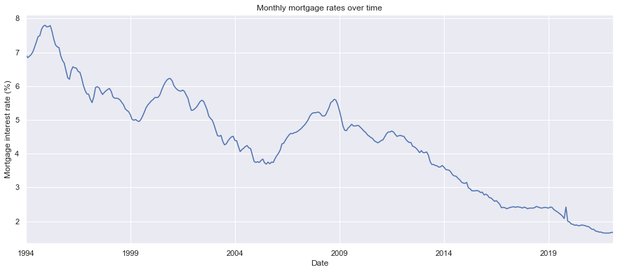

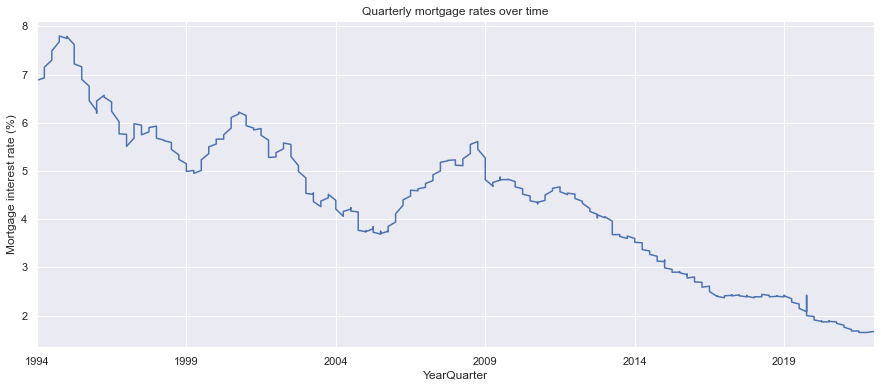

```python
#here i plot hte monthly and quarterly mortgage rates over time
option1.plot(x='Date', y='MortgageRate', title='Monthly mortgage rates over time', figsize=(15,6), legend=False)
plt.ylabel("Mortgage interest rate (%)")
option1.plot(x='YearQuarter', y='MortgageRate', title='Quarterly mortgage rates over time', figsize=(15,6), legend=False)
plt.ylabel("Mortgage interest rate (%)")
```

In the graph above you can see the mortgage rates over time. there seems to be a downwards trend with some random upwards development so here and there but overall a pretty smooth line (there aren't really spikes except at the end of 2019 there seems to be a small spike)

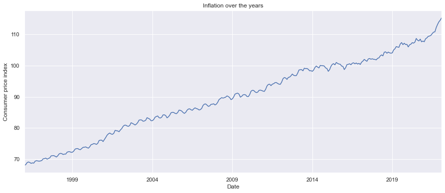

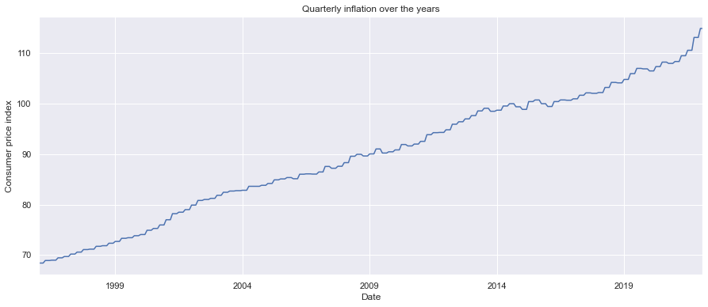

```python
#here i plot the inflation over time for both the monthly and quarterly numbers
InflationCleaned.plot(x='Date', y='CPI', title='Inflation over the years', figsize=(15,6), legend=False)
plt.ylabel("Consumer price index")
InflationCleaned.plot(x='Date', y='QuarterlyCPI', title='Quarterly inflation over the years', figsize=(15,6), legend=False)
plt.ylabel("Consumer price index")
```

Here I can see a very smooth upwards trend which nearly seems to be linear. if you look at the first graph it even looks like there is some sort of seasonal trend that slowly changes over time. you do see that the inflation raises quite a lot in 2021.

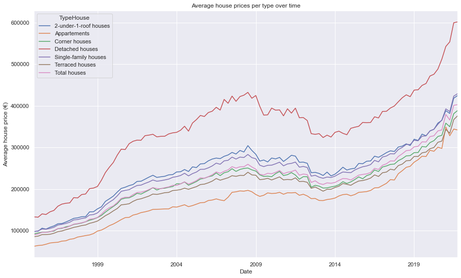

```python
#here i create a plot with the average houseprices over time with every type of house having its own line
HousepricesTypesHousesCleaned.pivot_table(values="AveragePrice", index="YearQuarter", columns="TypeHouse").plot(figsize=(15,9), title='Average house prices per type over time')
plt.ylabel("Average house price (€)")
plt.xlabel("Date")
```

In the graph above I can see that the different types of houses have a very similar way of growing over the year and so a very similar pattern, but they start and develop in different price classes and stay there (an apartment will always be the (or one of the) cheapest options so it is always the lowest line)

```
[Text(1, 0, '')]
```

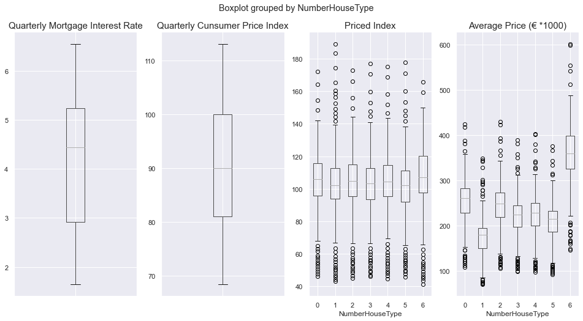

```python
#first i select the features i want ot feature in the boxplot
boxplot_features = tuple(CompleteDataset.columns[[1,2,5,6]].values)
CompleteDataset1=CompleteDataset
#then i add make every type of house a number so it it easier to show in thge box plot and later useable in the ml algerithm
CompleteDataset1['NumberHouseType']=CompleteDataset1['TypeHouse'].map({'2-under-1-roof houses':0,'Appartements':1,'Single-family houses':2,'Corner houses':3,'Total houses':4,'Terraced houses':5,'Detached houses':6})
#then i divide the average house prices by a thousant becuase other wise the axis will overlap the other plot
CompleteDataset1['AveragePrice * 1000']=CompleteDataset1['AveragePrice']/1000
#then i create the boxplots in a subplot so all the plots are next to each other and because the firsst 2 features are the same
#for all groups i dont make them per group
fig, (ax1, ax2, ax3, ax4) = plt.subplots(1, 4, figsize=(16,8))
CompleteDataset1.boxplot(column='QuarterlyRate', ax=ax1);
CompleteDataset1.boxplot(column='QuarterlyCPI', ax=ax2);
CompleteDataset1.boxplot(column='PriceIndex', by='NumberHouseType', ax=ax3);
CompleteDataset1.boxplot(column='AveragePrice * 1000', by='NumberHouseType', ax=ax4);
ax1.set_title("Quarterly Mortgage Interest Rate", fontsize=15)
ax2.set_title("Quarterly Cunsumer Price Index", fontsize=15)
ax3.set_title("Priced Index", fontsize=15)
ax4.set_title("Average Price (€ *1000)", fontsize=15)
label="Type of House"
ax1.set_xticklabels('')
ax2.set_xticklabels('')
```

In the boxplots you can, first of all, see that the first 2 don't have groups, this is because that data is not dependent on the group of types of houses. you can also see that the price index ranges are very similar to each other, but that is also very logical because then the development of the prices with 2015 being 100%. the last one gives the most variation in the ranges per type of house but the most different ones are group 1 (apartments) and group 6 (detached houses) and that is the case because those are the cheapest and most expensive types of houses you can find here in the Netherlands.

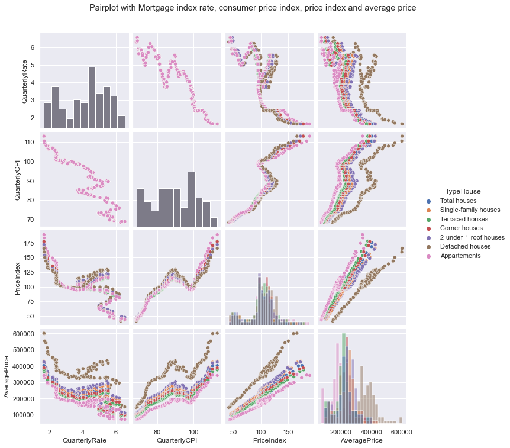

```python
#then i create a pair plot so we can see how each feature interacts with another feature and also how the data is distributed
pairplotData=CompleteDataset[['QuarterlyRate','QuarterlyCPI','TypeHouse' ,'PriceIndex', 'AveragePrice']]
pairplotData.index = range(728)
g=sns.pairplot(pairplotData, hue="TypeHouse", diag_kind="hist")
plt.suptitle('Pairplot with Mortgage index rate, consumer price index, price index and average price', y=1.05)
```

here you can see the scatter plots between each combination of features and the distribution. for the distribution both the Quarterly mortgage rates and the quarterly CPI are not normally distributed but are more uniformly distributed. the price index and average price do seem to be normally distributed but every one of the groups of data seems to be skewed. but to know that for sure I would need to plot each group separately.

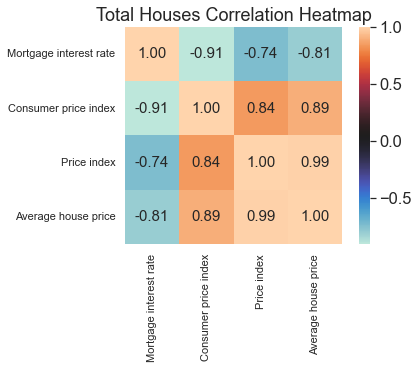

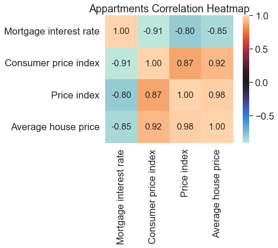

```python
#then i make a correlation heatmap for both the total houses and apartments
TotalHouses=CompleteDataset[CompleteDataset['TypeHouse']=='Total houses']

cols = ['QuarterlyRate', 'QuarterlyCPI', 'PriceIndex', 'AveragePrice']
labels=['Mortgage interest rate', 'Consumer price index', 'Price index', 'Average house price']

ax = plt.axes()
cm = np.corrcoef(TotalHouses[cols].values, rowvar=0)
sns.set(font_scale=1.5)
hm = sns.heatmap(cm,
    cbar=True,
    annot=True,
    square=True,
    fmt='.2f',
    annot_kws={'size': 15},
    yticklabels=labels,
    xticklabels=labels,
    cmap=sns.color_palette("icefire", as_cmap=True))
ax.set_title('Total Houses Correlation Heatmap')
plt.show()

Apartments=CompleteDataset[CompleteDataset['TypeHouse']=='Appartements']

ax1 = plt.axes()
cm = np.corrcoef(Apartments[cols].values, rowvar=0)
sns.set(font_scale=1.5)
hm = sns.heatmap(cm,
    cbar=True,
    annot=True,
    square=True,
    fmt='.2f',
    annot_kws={'size': 15},
    yticklabels=labels,
    xticklabels=labels,
    cmap=sns.color_palette("icefire", as_cmap=True))
ax1.set_title('Appartments Correlation Heatmap')
plt.show()
```

All the features in both of the house types are very highly correlated. this probably means that when I will try the regression models they will probably also be very accurate. you can also see that the last heatmap (apartments) is a bit higher in correlation than the one from the total houses.

## 1.6 Sources

Academica. (2021, May 20). Laagste hypotheekrente ooit: 0,83% 10 jaar vast! Academica.nl. Retrieved April 26, 2022, from https://www.academica.nl/artikelen/laagste-hypotheekrente-ooit-0-83-10-jaar-vast#:%7E:text=Ja%2C%20je%20leest%20het%20goed,Dit%20is%20een%20historisch%20laagterecord.Centraal  
Bureau voor de Statistiek. (2021, March 22). Gemiddelde verkoopprijs koopwoning in 2020 gestegen tot 334 duizend euro. Retrieved April 26, 2022, from https://www.cbs.nl/nl-nl/nieuws/2021/12/gemiddelde-verkoopprijs-koopwoning-in-2020-gestegen-tot-334-duizend-euro  
Rente.nl. (n.d.). Wat is de hypotheekrente historie? Retrieved April 26, 2022, from https://www.rente.nl/hypotheekrente/faq/hypotheekrente-historie